# Assignment 1

Elif Atılagn

29/10/2023

# İstanbul Stock Market Analysis

## **Task 1**

After storing both of thee data in different data frames, we start by taking a closer look at data formats:

```r
str(data_wide)
```

```
## Classes 'data.table' and 'data.frame':   50012 obs. of  61 variables:
##  $ timestamp: POSIXct, format: "2012-09-17 06:45:00" "2012-09-17 07:00:00" ...
##  $ AEFES    : num  22.4 22.4 22.4 22.4 22.6 ...
##  $ AKBNK    : num  5.21 5.19 5.21 5.19 5.21 ...
##  $ AKSA     : num  1.71 1.71 1.71 1.71 1.71 ...
##  $ AKSEN    : num  3.87 3.86 NA 3.86 3.87 3.86 NA 3.86 NA 3.86 ...
##  $ ALARK    : num  1.47 1.46 1.46 1.45 1.46 ...
##  $ ALBRK    : num  1.14 1.13 1.14 1.13 1.14 ...
##  $ ANACM    : num  1.06 1.06 1.07 1.07 1.07 ...
##  $ ARCLK    : num  6.99 6.93 6.99 6.96 6.99 ...
##  $ ASELS    : num  2.99 2.99 2.99 2.99 2.98 ...
##  $ ASUZU    : num  2.5 2.51 2.48 2.49 2.49 ...
##  $ AYGAZ    : num  3.54 3.55 3.55 3.54 3.54 ...
##  $ BAGFS    : num  37.5 37.3 37.3 37.4 37.5 ...
##  $ BANVT    : num  3.95 3.96 3.96 3.95 3.96 3.95 3.96 3.96 3.95 3.95 ...
```

[output cut: 48 more lines]

```r
str(data_long)
```

```
## Classes 'data.table' and 'data.frame':   2848030 obs. of  3 variables:
##  $ short_name: chr  "AEFES" "AEFES" "AEFES" "AEFES" ...
##  $ timestamp : POSIXct, format: "2012-09-17 06:45:00" "2012-09-17 07:00:00" ...
##  $ price     : num  22.4 22.4 22.4 22.4 22.6 ...
##  - attr(*, ".internal.selfref")=<externalptr>
```

```r
head(data_wide,10)
```

```
##               timestamp   AEFES  AKBNK   AKSA AKSEN  ALARK  ALBRK  ANACM  ARCLK
##  1: 2012-09-17 06:45:00 22.3978 5.2084 1.7102  3.87 1.4683 1.1356 1.0634 6.9909
##  2: 2012-09-17 07:00:00 22.3978 5.1938 1.7066  3.86 1.4574 1.1275 1.0634 6.9259
##  3: 2012-09-17 07:15:00 22.3978 5.2084 1.7102    NA 1.4610 1.1356 1.0679 6.9909
##  4: 2012-09-17 07:30:00 22.3978 5.1938 1.7102  3.86 1.4537 1.1275 1.0679 6.9584
##  5: 2012-09-17 07:45:00 22.5649 5.2084 1.7102  3.87 1.4574 1.1356 1.0725 6.9909
##  6: 2012-09-17 08:00:00 22.5649 5.2229 1.7102  3.86 1.4610 1.1275 1.0725 6.9584
##  7: 2012-09-17 08:15:00 22.5649 5.2229 1.7066    NA 1.4610 1.1275 1.0679 6.9584
##  8: 2012-09-17 08:30:00 22.5649 5.2084 1.7066  3.86 1.4610     NA 1.0725 6.9909
##  9: 2012-09-17 08:45:00 22.5649 5.2372 1.6995    NA 1.4610 1.1275 1.0725 6.9909
## 10: 2012-09-17 09:00:00 22.5649 5.2372 1.6995  3.86 1.4610 1.1356 1.0725 6.9909
##      ASELS  ASUZU  AYGAZ   BAGFS BANVT  BRISA   CCOLA CEMAS  ECILC  EREGL
##  1: 2.9948 2.4998 3.5396 37.4875  3.95 3.9666 27.2590  1.20 0.8046 0.7914
##  2: 2.9948 2.5100 3.5483 37.2769  3.96 3.9666 27.3471  1.19 0.8088 0.7844
##  3: 2.9855 2.4796 3.5483 37.2769  3.96 3.9356 27.3471  1.19 0.8088 0.7914
```

[output cut: 51 more lines]

```r
head(data_long,10)
```

```
##     short_name           timestamp   price
##  1:      AEFES 2012-09-17 06:45:00 22.3978
##  2:      AEFES 2012-09-17 07:00:00 22.3978
##  3:      AEFES 2012-09-17 07:15:00 22.3978
##  4:      AEFES 2012-09-17 07:30:00 22.3978
##  5:      AEFES 2012-09-17 07:45:00 22.5649
##  6:      AEFES 2012-09-17 08:00:00 22.5649
##  7:      AEFES 2012-09-17 08:15:00 22.5649
##  8:      AEFES 2012-09-17 08:30:00 22.5649
##  9:      AEFES 2012-09-17 08:45:00 22.5649
## 10:      AEFES 2012-09-17 09:00:00 22.5649
```

```r
summary(data_wide)
```

```
##    timestamp                          AEFES             AKBNK
##  Min.   :2012-09-17 06:45:00.00   Min.   : 0.0001   Min.   :0.0001
##  1st Qu.:2014-08-12 13:11:15.00   1st Qu.:19.1605   1st Qu.:5.8500
##  Median :2016-05-13 11:22:30.00   Median :20.6465   Median :6.3057
##  Mean   :2016-04-12 21:51:05.74   Mean   :20.9822   Mean   :6.4731
##  3rd Qu.:2017-12-22 11:03:45.00   3rd Qu.:22.7320   3rd Qu.:6.9325
##  Max.   :2019-07-23 15:00:00.00   Max.   :28.5090   Max.   :9.2124
##                                   NA's   :1881      NA's   :803
##       AKSA             AKSEN           ALARK            ALBRK
##  Min.   : 0.0001   Min.   :0.000   Min.   :0.0001   Min.   :1.026
##  1st Qu.: 5.2088   1st Qu.:2.670   1st Qu.:1.5689   1st Qu.:1.225
##  Median : 6.9853   Median :2.930   Median :1.9376   Median :1.360
##  Mean   : 7.1275   Mean   :3.183   Mean   :2.0609   Mean   :1.365
##  3rd Qu.: 8.7200   3rd Qu.:3.750   3rd Qu.:2.4214   3rd Qu.:1.500
##  Max.   :15.1189   Max.   :5.190   Max.   :3.5143   Max.   :2.190
##  NA's   :1418      NA's   :1841    NA's   :1677     NA's   :3150
##      ANACM            ARCLK             ASELS             ASUZU
##  Min.   :0.0001   Min.   : 0.0001   Min.   : 0.0001   Min.   : 0.0001
##  1st Qu.:1.0470   1st Qu.:11.7111   1st Qu.: 4.9403   1st Qu.: 5.0748
##  Median :1.2597   Median :15.0100   Median : 9.2757   Median : 5.9496
##  Mean   :1.6721   Mean   :15.3881   Mean   :13.4325   Mean   : 6.4670
##  3rd Qu.:2.4021   3rd Qu.:19.0877   3rd Qu.:22.7567   3rd Qu.: 7.1200
##  Max.   :3.5021   Max.   :26.4278   Max.   :46.7616   Max.   :15.2800
##  NA's   :1847     NA's   :967       NA's   :1209      NA's   :1579
##      AYGAZ             BAGFS             BANVT            BRISA
##  Min.   : 0.0001   Min.   : 0.0001   Min.   : 0.000   Min.   : 0.0001
##  1st Qu.: 5.9515   1st Qu.: 8.2618   1st Qu.: 2.590   1st Qu.: 5.8900
##  Median : 7.7238   Median :10.6100   Median : 3.710   Median : 6.7300
##  Mean   : 8.1019   Mean   :10.4071   Mean   : 7.628   Mean   : 6.5449
##  3rd Qu.:10.2690   3rd Qu.:12.3500   3rd Qu.:11.930   3rd Qu.: 7.3300
##  Max.   :13.5935   Max.   :38.4352   Max.   :28.680   Max.   :10.3275
##  NA's   :1893      NA's   :1362      NA's   :2061     NA's   :1075
##      CCOLA             CEMAS           ECILC            EREGL
##  Min.   : 0.0001   Min.   :0.000   Min.   :0.0001   Min.   : 0.0001
##  1st Qu.:31.9782   1st Qu.:0.700   1st Qu.:1.1723   1st Qu.: 2.1812
##  Median :34.8215   Median :0.870   Median :1.8214   Median : 3.0360
##  Mean   :36.8907   Mean   :1.209   Mean   :2.0759   Mean   : 4.1795
##  3rd Qu.:42.0497   3rd Qu.:1.500   3rd Qu.:2.7809   3rd Qu.: 6.7587
##  Max.   :54.2208   Max.   :7.010   Max.   :4.2278   Max.   :10.4710
##  NA's   :1263      NA's   :3618    NA's   :1520     NA's   :839
```

[output cut: 73 more lines]

```
##  Min.   :0.0001   Min.   : 0.000   Min.   : 0.000   Min.   :0.0001
##  1st Qu.:4.0322   1st Qu.: 4.020   1st Qu.: 0.389   1st Qu.:2.2682
##  Median :4.4742   Median : 6.320   Median : 0.966   Median :2.6093
##  Mean   :4.7354   Mean   : 5.943   Mean   : 2.434   Mean   :2.5663
##  3rd Qu.:5.2460   3rd Qu.: 7.450   3rd Qu.: 4.230   3rd Qu.:2.8740
##  Max.   :7.5814   Max.   :14.540   Max.   :10.675   Max.   :3.9581
##  NA's   :800      NA's   :1231     NA's   :3957     NA's   :787
##      YUNSA           ZOREN
##  Min.   :0.000   Min.   :0.0001
##  1st Qu.:3.007   1st Qu.:1.0338
##  Median :4.108   Median :1.2500
##  Mean   :4.080   Mean   :1.2481
##  3rd Qu.:4.721   3rd Qu.:1.4265
##  Max.   :9.528   Max.   :2.4430
##  NA's   :4484    NA's   :1205
```

```r
summary(data_long)
```

```
##   short_name          timestamp                          price
##  Length:2848030     Min.   :2012-09-17 06:45:00.00   Min.   :  0.000
##  Class :character   1st Qu.:2014-08-28 07:00:00.00   1st Qu.:  1.764
##  Mode  :character   Median :2016-06-02 09:45:00.00   Median :  4.428
##                     Mean   :2016-04-26 08:05:50.16   Mean   :  9.282
##                     3rd Qu.:2018-01-05 07:15:00.00   3rd Qu.:  9.280
##                     Max.   :2019-07-23 15:00:00.00   Max.   :139.429
```

Here, we learn that each column is numerical except for timestamp in the wide data and we learn the format of the timestamp. Summarizing the long data we learn that the data is recorded from 2012-09-17 6:45 to 2019-07-23 15:00. We also learn the price range for all closing prices which is 139.429. Summarizing the wide data, we get a feeling of each company’s closing prices’ distributions and shapes. We can see important statistics like mean or median for closing prices of each company.

Easy way to check how many rows there are with missing values in wide data is the following:

```r
sum(!complete.cases(data_wide))
```

```
## [1] 40784
```

```r
colSums(is.na(data_wide))
```

```
## timestamp     AEFES     AKBNK      AKSA     AKSEN     ALARK     ALBRK     ANACM
##         0      1881       803      1418      1841      1677      3150      1847
##     ARCLK     ASELS     ASUZU     AYGAZ     BAGFS     BANVT     BRISA     CCOLA
##       967      1209      1579      1893      1362      2061      1075      1263
##     CEMAS     ECILC     EREGL     FROTO     GARAN     GOODY     GUBRF     HALKB
##      3618      1520       839      1017       704      1051       955       941
##     ICBCT     ISCTR     ISDMR     ISFIN     ISYAT     KAREL     KARSN     KCHOL
##      5676       791     37785      7135      6828      3980      1485       919
##     KRDMB     KRDMD     MGROS     OTKAR     PARSN     PETKM     PGSUS     PRKME
##      2480       851      1109      1227      4687       828      4791      1546
##     SAHOL      SASA      SISE     SKBNK      SODA     TCELL     THYAO     TKFEN
##       917      2379       922      2742      1736       869       730      1082
##     TOASO     TRKCM      TSKB     TTKOM     TUKAS     TUPRS      USAK     VAKBN
##      1066      1126      1628       935      4083       869      2353       800
##     VESTL     YATAS     YKBNK     YUNSA     ZOREN
##      1231      3957       787      4484      1205
```

If we look at it in terms of columns,around 75% of ISDMR’s closing prices are missing.Even the second column with most missing data is only lacking 14% of data points. A quick Google search reveals that ISDMR joined the stock market in 2016, and since data is from 2012-2019, only 3 years of data is recorded. We may choose to delete this column from the data later on.

Plots below gives us a general picture of the stock prices data for two different groups of instances.

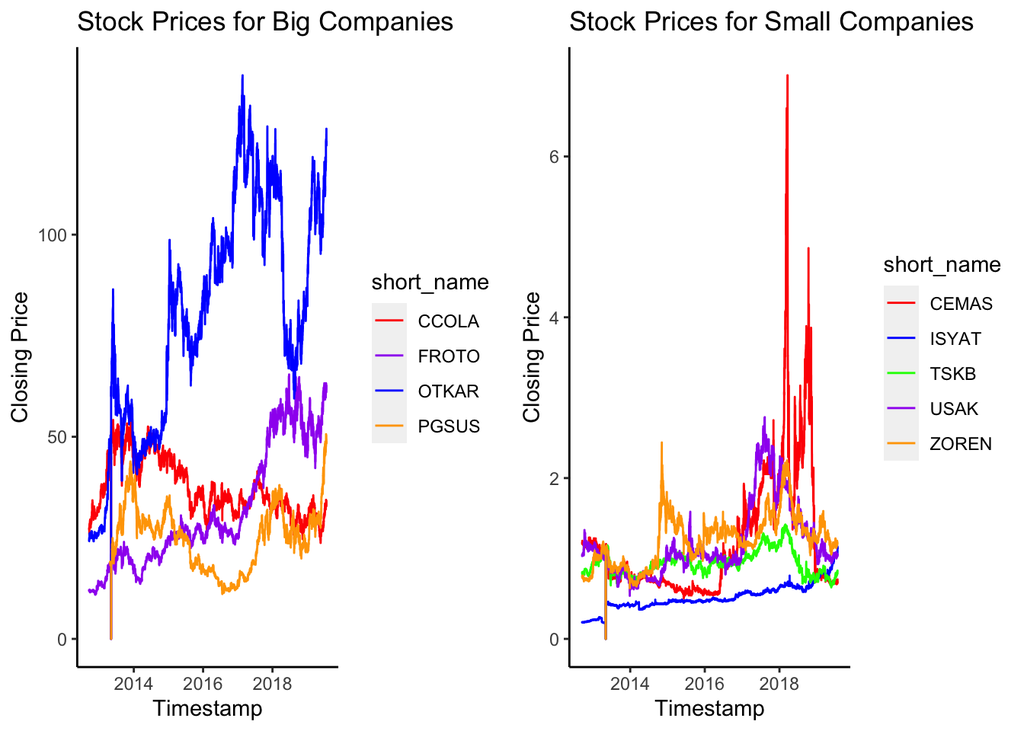

```r
library(gridExtra)
grid.arrange(big_plot, small_plot, ncol = 2)
```

To identify patterns, we may choose to look at moving averages. I chose some random stocks that I am interested in, namely “ARCLK”,“ASELS”,“CCOLA”,“AEFES”,“YATAS”.

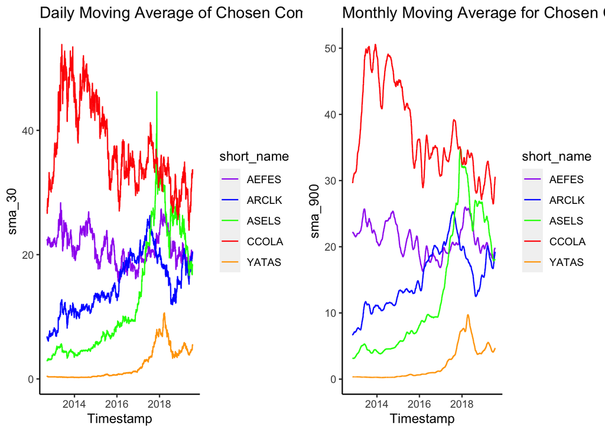

```r
companies <- c("ARCLK","ASELS","CCOLA","AEFES","YATAS")
# Create empty data frame to store the results
sma <- data.frame()

# Iterate through the list of companies and calculate moving averages
for (company in companies) {
  data <- data_long[data_long$short_name %in% company, ]

  # Calculate 30-timestamp Simple Moving Average which on the average corresponds to a working day
  data$sma_30 <- SMA(data$price, n = 30)

  # Calculate 900-timestamp Simple Moving Average which on the average corresponds to a month
  data$sma_900 <- SMA(data$price, n = 900)

  # Append the results to the respective data frames
  sma <- rbind(sma, data)
}

# Now we can move on with the visualization

SMA30_plot <- ggplot(sma, aes(x = timestamp, y = sma_30, color = short_name)) +
  geom_line() +
  labs(title = "Daily Moving Average of Chosen Companies",
       x = "Timestamp") +
  scale_color_manual(values = c("ARCLK" = "blue", "ASELS" = "green", "CCOLA" = "red", "AEFES" = "purple", "YATAS" = "orange")) +
  theme(panel.grid.major = element_blank(), panel.grid.minor = element_blank(),
        panel.background = element_blank(), axis.line = element_line(colour = "black"))

SMA900_plot <- ggplot(sma, aes(x = timestamp, y = sma_900, color = short_name)) +
  geom_line() +
  labs(title = "Monthly Moving Average for Chosen Companies",
       x = "Timestamp") +
  scale_color_manual(values = c("ARCLK" = "blue", "ASELS" = "green", "CCOLA" = "red", "AEFES" = "purple", "YATAS" = "orange")) +
  theme(panel.grid.major = element_blank(), panel.grid.minor = element_blank(),
        panel.background = element_blank(), axis.line = element_line(colour = "black"))
grid.arrange(SMA30_plot, SMA900_plot, ncol = 2)
```

We can see from the graph that the underlying trend does not change since stock prices of very known companies show relatively low volatility. Monthly MA is the somewhat smoothed version of the daily MA due to aggregation.

Since we are going to work with wide data in most analyses other than visualizations, I will look at the structure of the wide data more carefully.

```r
summary <- describe(data_wide[,-1])
print(summary)
```

```
##       vars     n  mean    sd median trimmed   mad  min    max  range  skew
## AEFES    1 48131 20.98  2.49  20.65   20.89  2.55 0.00  28.51  28.51  0.31
## AKBNK    2 49209  6.47  0.94   6.31    6.41  0.75 0.00   9.21   9.21  0.58
## AKSA     3 48594  7.13  2.71   6.99    7.10  2.61 0.00  15.12  15.12  0.17
## AKSEN    4 48171  3.18  0.72   2.93    3.11  0.59 0.00   5.19   5.19  0.83
## ALARK    5 48335  2.06  0.58   1.94    2.01  0.61 0.00   3.51   3.51  0.65
## ALBRK    6 46862  1.37  0.17   1.36    1.36  0.20 1.03   2.19   1.16  0.39
## ANACM    7 48165  1.67  0.79   1.26    1.59  0.52 0.00   3.50   3.50  0.71
## ARCLK    8 49045 15.39  4.53  15.01   15.34  5.43 0.00  26.43  26.43  0.12
## ASELS    9 48803 13.43  9.62   9.28   12.44  7.35 0.00  46.76  46.76  0.70
## ASUZU   10 48433  6.47  2.20   5.95    6.15  1.41 0.00  15.28  15.28  1.48
## AYGAZ   11 48119  8.10  2.61   7.72    8.02  2.96 0.00  13.59  13.59  0.30
## BAGFS   12 48650 10.41  3.62  10.61   10.32  2.85 0.00  38.44  38.44  2.97
## BANVT   13 47951  7.63  6.27   3.71    6.63  2.12 0.00  28.68  28.68  1.01
## BRISA   14 48937  6.54  1.30   6.73    6.57  1.06 0.00  10.33  10.33 -0.17
## CCOLA   15 48749 36.89  6.75  34.82   36.41  6.03 0.00  54.22  54.22  0.61
## CEMAS   16 46394  1.21  0.80   0.87    1.06  0.39 0.00   7.01   7.01  2.35
## ECILC   17 48492  2.08  0.97   1.82    2.00  1.06 0.00   4.23   4.23  0.50
## EREGL   18 49173  4.18  2.69   3.04    3.99  2.39 0.00  10.47  10.47  0.57
## FROTO   19 48995 32.76 14.73  27.12   31.93 11.49 0.00  65.42  65.42  0.57
## GARAN   20 49308  7.90  1.25   7.65    7.81  1.08 0.00  12.16  12.16  0.66
## GOODY   21 48961  3.10  0.89   3.19    3.08  0.86 0.00  58.76  58.76 10.20
## GUBRF   22 49057  4.33  1.22   4.25    4.24  1.36 0.00  13.62  13.62  0.50
## HALKB   23 49071 10.92  3.07  10.65   10.87  3.36 0.00  20.24  20.24  0.21
## ICBCT   24 44336  2.83  1.79   2.03    2.58  0.97 0.00  11.27  11.27  1.49
## ISCTR   25 49221  5.13  1.00   4.85    5.03  0.97 0.00   7.96   7.96  0.70
## ISDMR   26 12227  5.35  1.70   5.91    5.61  1.14 1.02   7.59   6.58 -1.23
## ISFIN   27 42877  1.56  1.76   0.86    1.14  0.49 0.00   9.83   9.83  2.17
## ISYAT   28 43184  0.54  0.16   0.50    0.53  0.12 0.00   1.15   1.15  0.53
## KAREL   29 46032  3.18  2.13   1.82    2.90  0.76 0.00   9.46   9.46  0.86
## KARSN   30 48527  1.33  0.29   1.29    1.30  0.26 0.00   2.50   2.50  1.03
## KCHOL   31 49093 12.25  3.18  12.04   12.24  3.98 0.00  19.15  19.15  0.04
## KRDMB   32 47532  2.22  0.69   2.20    2.17  0.86 0.00   4.50   4.50  0.49
## KRDMD   33 49161  1.77  0.94   1.40    1.60  0.63 0.00   4.95   4.95  1.37
## MGROS   34 48903 19.58  3.90  19.11   19.34  4.05 0.00  30.26  30.26  0.47
## OTKAR   35 48785 81.42 27.78  82.82   82.33 35.70 0.00 139.43 139.43 -0.23
## PARSN   36 45325  8.28  4.66   7.89    7.79  4.57 0.00  29.82  29.82  1.12
## PETKM   37 49184  2.54  1.38   2.28    2.44  1.68 0.00   5.77   5.77  0.47
## PGSUS   38 45221 24.79  7.66  25.64   24.57  7.95 0.00  50.65  50.65  0.22
## PRKME   39 48466  2.93  0.72   2.74    2.87  0.65 0.00   5.43   5.43  0.66
```

[output cut: 67 more lines]

```
## THYAO    -0.33 0.02
## TKFEN     0.01 0.03
## TOASO    -1.01 0.03
## TRKCM    -0.99 0.00
## TSKB      0.12 0.00
## TTKOM     0.45 0.00
## TUKAS     3.24 0.00
## TUPRS    -0.97 0.15
## USAK      0.83 0.00
## VAKBN    -0.07 0.00
## VESTL    -0.37 0.01
## YATAS     0.09 0.01
## YKBNK     0.02 0.00
## YUNSA     0.76 0.01
## ZOREN     0.27 0.00
```

These table can be commented on based on some different perspectives:

*a. Company variability:* Table shows the variety in the stock data of different companies. For example, “OTKAR” has a substantial range with high maximum value, may be indicating high price fluctuations, while “ISYAT” has a much smaller range suggesting less volatility.

*b. Central Tendency:* The mean and median values indicate the central tendency of the stock prices for each company. “OTKAR” has the highest mean and median, implying higher average prices compared to others.

*d. Trimmed mean:* Trimmed mean and median absolute deviation (mad) are robust measures of central tendency and dispersion,respectively.They are less affected by outliers. For example, “TCELL” has a trimmed mean closer to its median, suggesting less influence of outliers.

*e. Skewness and Kurtosis:* They indicate the shape of the distribution of stock prices. A positive skew indicates a right-skewed distribution while negative skewness indicates a left-skewed distribution. “GOODY” has a highly positively skewed distribution. Kurtosis measures the “tailedness” of the distribution. Positive kurtosis suggests heave tails, while negative kurtosis suggests light tails. “GOODY” has a very high kurtosis, indicating heavy tails.

*f. Min and Max values:* The minimum and maximum values provide insights into the extreme values within the dataset. For example, “GOODY” has a very high maximum value while “ALBRK” has a relatively low maximum value.

*g. Data Quality:* We should be aware of extreme values and potential outliers in the data, especially when interpreting statistics. So, the following method is watched:

```r
summary$pc_difference <- (abs(summary$mean - summary$trimmed))*100/summary$mean
head(summary[order(summary$pc_difference,decreasing=TRUE),],6)
```

```
##       vars     n mean   sd median trimmed  mad min   max range skew kurtosis
## ISFIN   27 42877 1.56 1.76   0.86    1.14 0.49   0  9.83  9.83 2.17     4.17
## YATAS   57 46055 2.43 2.55   0.97    2.02 1.03   0 10.67 10.67 1.07     0.09
## SASA    41 47633 2.29 2.49   0.73    1.98 0.70   0  8.43  8.43 0.83    -1.02
## BANVT   13 47951 7.63 6.27   3.71    6.63 2.12   0 28.68 28.68 1.01    -0.01
## CEMAS   16 46394 1.21 0.80   0.87    1.06 0.39   0  7.01  7.01 2.35     7.84
## TKFEN   47 48930 9.19 6.67   5.75    8.09 2.80   0 27.32 27.32 1.17     0.01
##         se pc_difference
## ISFIN 0.01         26.58
## YATAS 0.01         16.93
## SASA  0.01         13.52
## BANVT 0.03         13.13
## CEMAS 0.00         12.40
## TKFEN 0.03         12.01
```

These six are the stocks with outliers that drastically changes the mean (percentage-wise) compared to others.

## **Task 2**

```r
#ggpairs(data_wide[,-1])
#ggcorrplot(data_wide[,-1])

cor_matrix <- cor(data_wide[,-1],use="na.or.complete")
max(cor_matrix[which(cor_matrix <1)])
```

```
## [1] 0.9340109
```

Looking at the table we see that the maximum correlation is between “SAHOL” & “AKBNK”. Closely followed by “MGROS” & “TSKB”.”SAHOL” is also highly correlated with “TTKOM”.

- **a. SAHOL-AKBNK** By aggregating data, we calculate monthly correlations between the stock closing prices of “SAHOL” and “AKBNK”.

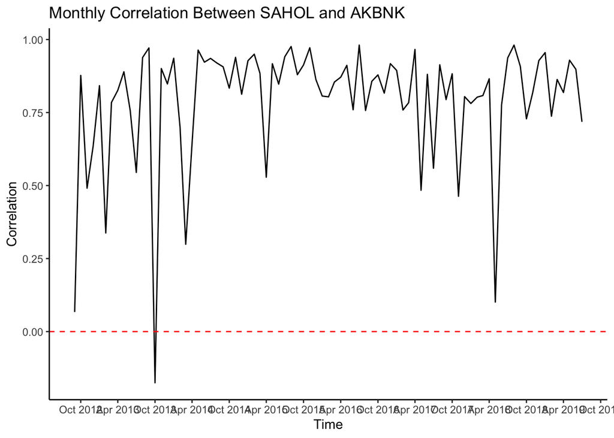

```r
# Visualize the monthly correlations
ggplot(monthly_correlations, aes(x = Month, y = Correlation)) +
  geom_line() +
  scale_x_date(date_breaks = "6 months", date_labels = "%b %Y") +
  geom_hline(yintercept = 0, linetype = "dashed", color = "red")+
  labs(title = "Monthly Correlation Between SAHOL and AKBNK",
       x = "Time",
       y = "Correlation")+
  theme(panel.grid.major = element_blank(), panel.grid.minor = element_blank(),
        panel.background = element_blank(), axis.line = element_line(colour = "black"))
```

If we look at the graph SAHOL and AKBNK are highly correlated most of the time,this is to be expected considering the fact that AKBNK is SAHOL’s company. There is an all-time-low in October 2013 in which SAHOL’s closing prices dropped by 4% whereas AKBNK’s increased by the same ratio, to find the reason we need to know more about the dynamics, business operations, and the context. If we take a closer look at the correlations table we see a fall almost every three months, this could be added to the model as seasonality for further analysis.

- **b. MGROS- TSKB** The same thing is performed for the “MGROS” and “TSKB” stock closing prices.

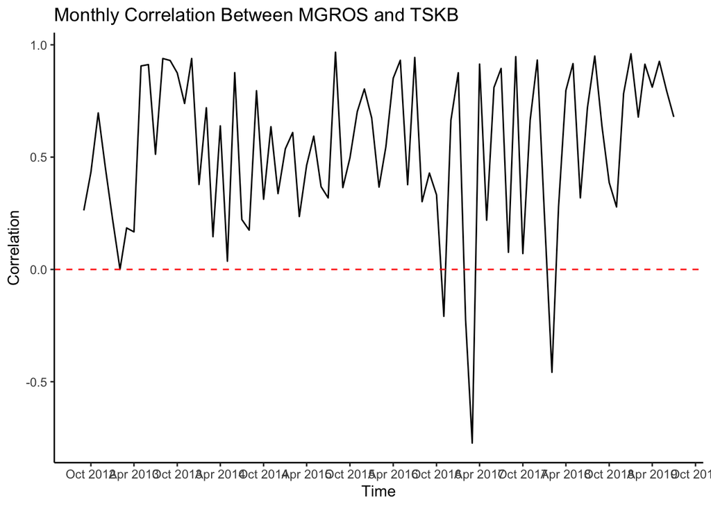

```r
# Visualize the monthly correlations
ggplot(monthly_correlations1, aes(x = Month, y = Correlation)) +
  geom_line() +
  scale_x_date(date_breaks = "6 months", date_labels = "%b %Y") +
  geom_hline(yintercept = 0, linetype = "dashed", color = "red")+
  labs(title = "Monthly Correlation Between MGROS and TSKB",
       x = "Time",
       y = "Correlation")+
  theme(panel.grid.major = element_blank(), panel.grid.minor = element_blank(),
        panel.background = element_blank(), axis.line = element_line(colour = "black"))
```

- **c. SAHOL-TTKOM** Finally, we examine the monthly correlation between “SAHOL” and “TTKOM” stock prices.

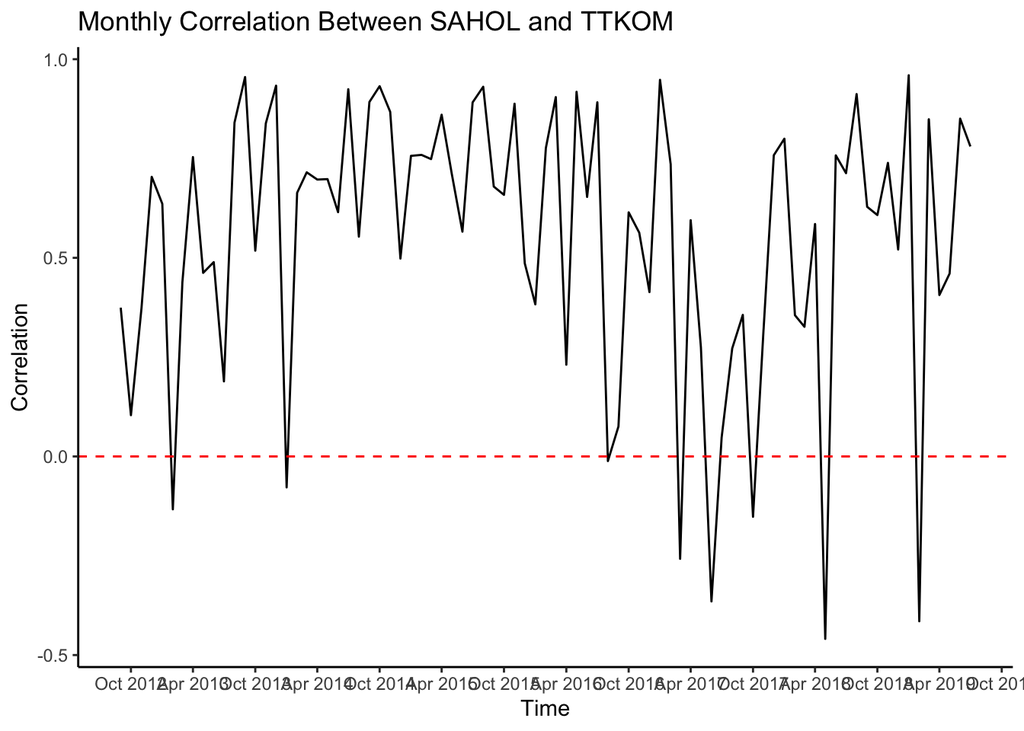

```r
# Visualize the monthly correlations
ggplot(monthly_correlations2, aes(x = Month, y = Correlation)) +
  geom_line() +
  scale_x_date(date_breaks = "6 months", date_labels = "%b %Y") +
  geom_hline(yintercept = 0, linetype = "dashed", color = "red")+
  labs(title = "Monthly Correlation Between SAHOL and TTKOM",
       x = "Time",
       y = "Correlation")+
  theme(panel.grid.major = element_blank(), panel.grid.minor = element_blank(),
        panel.background = element_blank(), axis.line = element_line(colour = "black"))
```

When we look at the graph we see serious unusual negative correlation between SAHOL and TTKOM around 2018 May.More generally, around spring months between 2017 and 2019, SAHOL and TTKOM stock prices changes in different directions drastically with respect to each other. However, the situation quickly changes when it comes to summer and they are positively correlated and it stays that way most of the year. There is always ups and downs between these two stocks, even if the correlation does not change sign.

## **Task 3**

```r
data_wide_cleaned <- na.omit(data_wide)
pca_obj = princomp(data_wide_cleaned[,-1],cor=T)
summary(pca_obj,loadings=T)
```

```
## Importance of components:
##                           Comp.1    Comp.2    Comp.3     Comp.4     Comp.5
## Standard deviation     4.4239769 3.8883916 3.3072315 1.91257436 1.66717858
## Proportion of Variance 0.3261929 0.2519931 0.1822963 0.06096568 0.04632474
## Cumulative Proportion  0.3261929 0.5781860 0.7604824 0.82144803 0.86777277
##                            Comp.6     Comp.7     Comp.8     Comp.9     Comp.10
## Standard deviation     1.36579977 0.99989145 0.88306889 0.80862554 0.705379875
## Proportion of Variance 0.03109015 0.01666305 0.01299684 0.01089792 0.008292679
## Cumulative Proportion  0.89886292 0.91552597 0.92852281 0.93942073 0.947713414
##                            Comp.11     Comp.12     Comp.13     Comp.14
## Standard deviation     0.634050398 0.583702845 0.533534141 0.475672150
## Proportion of Variance 0.006700332 0.005678484 0.004744311 0.003771067
## Cumulative Proportion  0.954413746 0.960092230 0.964836541 0.968607607
##                           Comp.15     Comp.16     Comp.17     Comp.18
## Standard deviation     0.43232767 0.387851270 0.360380443 0.354355410
## Proportion of Variance 0.00311512 0.002507143 0.002164568 0.002092796
## Cumulative Proportion  0.97172273 0.974229871 0.976394439 0.978487235
##                            Comp.19     Comp.20     Comp.21     Comp.22
## Standard deviation     0.340673277 0.317299565 0.297948139 0.286828997
## Proportion of Variance 0.001934305 0.001677984 0.001479552 0.001371181
## Cumulative Proportion  0.980421540 0.982099523 0.983579075 0.984950256
##                            Comp.23     Comp.24     Comp.25      Comp.26
## Standard deviation     0.280243283 0.262694050 0.249617186 0.2416969251
## Proportion of Variance 0.001308938 0.001150136 0.001038479 0.0009736234
## Cumulative Proportion  0.986259194 0.987409330 0.988447809 0.9894214326
##                             Comp.27      Comp.28      Comp.29      Comp.30
## Standard deviation     0.2285949271 0.2123262991 0.2051813764 0.1982332310
## Proportion of Variance 0.0008709273 0.0007513743 0.0007016566 0.0006549402
## Cumulative Proportion  0.9902923600 0.9910437343 0.9917453909 0.9924003311
##                             Comp.31      Comp.32      Comp.33      Comp.34
## Standard deviation     0.1908398076 0.1853507848 0.1706826757 0.1669624976
## Proportion of Variance 0.0006069972 0.0005725819 0.0004855429 0.0004646079
## Cumulative Proportion  0.9930073283 0.9935799102 0.9940654531 0.9945300611
##                             Comp.35     Comp.36      Comp.37      Comp.38
## Standard deviation     0.1590024279 0.155843187 0.1553781484 0.1460474553
## Proportion of Variance 0.0004213629 0.000404785 0.0004023728 0.0003554977
## Cumulative Proportion  0.9949514239 0.995356209 0.9957585817 0.9961140794
##                             Comp.39      Comp.40      Comp.41      Comp.42
## Standard deviation     0.1403824046 0.1320562490 0.1287146393 0.1265162697
## Proportion of Variance 0.0003284537 0.0002906475 0.0002761243 0.0002667728
```

[output cut: 435 more lines]

```
## THYAO          0.302           0.115
## TKFEN  0.187  -0.253
## TOASO                  0.107
## TRKCM  0.104   0.116           0.113
## TSKB          -0.182
## TTKOM  0.131           0.120
## TUKAS          0.127   0.214   0.325
## TUPRS -0.249   0.147  -0.132
## USAK  -0.208  -0.149
## VAKBN -0.341          -0.403   0.435   0.157
## VESTL -0.159
## YATAS         -0.159   0.108
## YKBNK -0.140   0.596   0.103  -0.285
## YUNSA                          0.111
## ZOREN
```

First thing we observe that first 6 components cover almost 90% of variance and the second half of the components just explain the last 1% of the variance.Since the model is huge I am only able to see the stocks till CEMAS for the loadings and will base my comments on this. This wouldn’t affect my performance since I don’t have that much knowledge about stock prices anyway.For this reason, I will only closely examine the first 4 components that cover more than 80% of the variance:

- *Comp1* This index can be regarded as the effect of big holding companies on the stock prices. These companies are well-established millionaire-family (like Koç and Sabancı) or international megastars like Coca Cola.This companies stocks also paint a good picture of the general market trend.
- *Comp2* Component 2 shows the positive correlation between AKSA,ANACM,ASELS,ASUZU,BANVT as opposed to ARCLK and BAGFS. It is hard to comment on this without knowing specific market dynamics however,I feel like the first group of stocks belong to companies that are highly favored and supported by the government.
- *Comp3* Component 3 shows loadings primarily on AKSEN, CEMAS as opposed to AKBNK,ALARK,ARCLK. It suggests that these stocks have some common underlying pattern or factor affecting their prices. This component might capture a sector-specific trend or economic factors impacting these stocks.
- *Comp4* Again, component 4 divides the data into two group. One group has AKSA,ALARK,ASUZU,BAGFS and the other has ALBRK,ASELS,AYGAZ,BRISA. It is again hard to comment on this without knowing market specifics or underlying economic factors.

## **Task 4**

In this section, I will examine Google Trends data to see if the correlation pattern of the closing stock prices of the companies I compared in task 2 holds for Google search as well.

- **SAHOL-AKBNK**

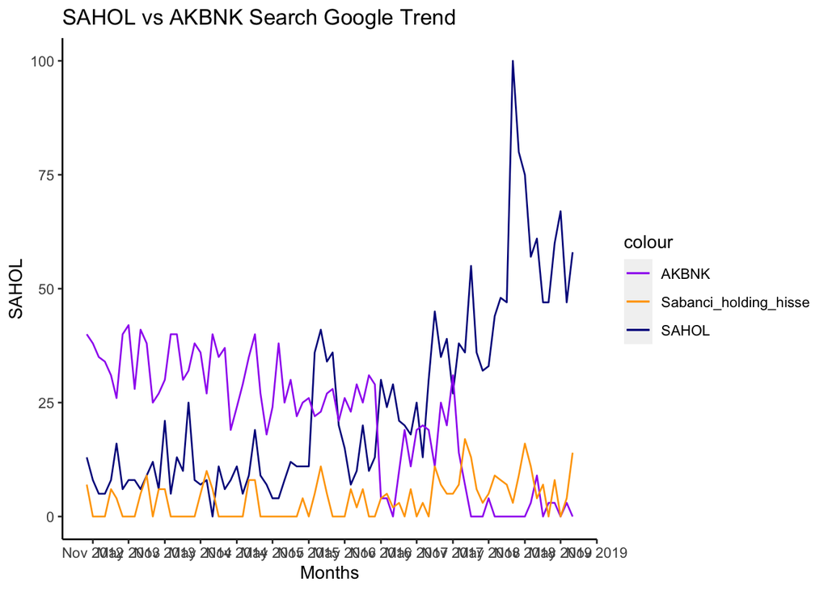

```r
ggplot(sahol_akbnk, aes(x = Month)) +
  geom_line(aes(y=SAHOL,colour="SAHOL")) +
  geom_line(aes(y=AKBNK, colour= "AKBNK")) +
  geom_line(aes(y=Sabanci_holding_hisse, colour= "Sabanci_holding_hisse"))+
  scale_x_date(date_breaks = "6 months", date_labels = "%b %Y") +
  labs(title = "SAHOL vs AKBNK Search Google Trend",
       x = "Months") +
  scale_color_manual(values = c("SAHOL" = "darkblue", "AKBNK" = "purple", "Sabanci_holding_hisse" = "orange")) +
  theme(panel.grid.major = element_blank(), panel.grid.minor = element_blank(),
        panel.background = element_blank(), axis.line = element_line(colour = "black"))
```

The graph shows the number of times “IST:SAHOL”, “IST:AKBNK”, and “Sabancı holding hisse yorum” have been Googled from 2012 to 2019 with respect to time. It looks promising but what we are interested in are the correlation information between “SAHOL” and “AKBNK”.

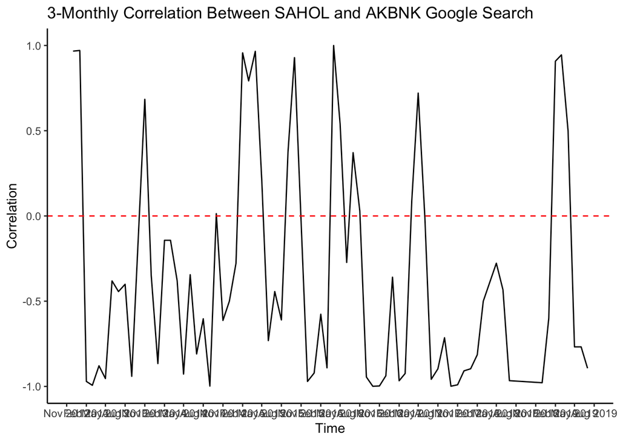

```r
# Visualize the monthly correlations
SA_correlations = na.omit(SA_correlations)
ggplot(SA_correlations, aes(x = Month, y = corr)) +
  geom_line() +
  scale_x_date(date_breaks = "3 months", date_labels = "%b %Y") +
  labs(title = "3-Monthly Correlation Between SAHOL and AKBNK Google Search",
       x = "Time",
       y = "Correlation") +
  geom_hline(yintercept = 0, linetype = "dashed", color = "red")+
  theme(panel.grid.major = element_blank(), panel.grid.minor = element_blank(),
        panel.background = element_blank(), axis.line = element_line(colour = "black"))
```

- **MGROS-TSKB**

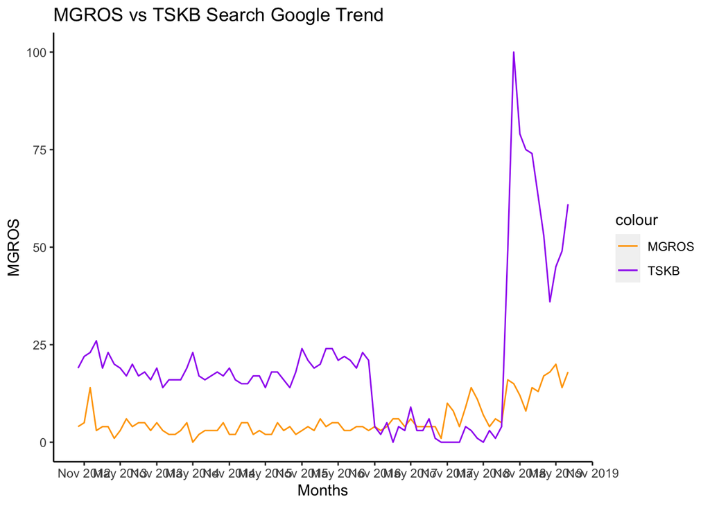

```r
ggplot(mgros_tskb, aes(x = Month)) +
  geom_line(aes(y=MGROS,colour="MGROS")) +
  geom_line(aes(y=TSKB, colour= "TSKB")) +
  scale_x_date(date_breaks = "6 months", date_labels = "%b %Y") +
  labs(title = "MGROS vs TSKB Search Google Trend",
       x = "Months") +
  scale_color_manual(values = c("MGROS" = "orange", "TSKB" = "purple")) +
  theme(panel.grid.major = element_blank(), panel.grid.minor = element_blank(),
        panel.background = element_blank(), axis.line = element_line(colour = "black"))
```

Looking at the correlations for Google search of “IST:MGROS” and “IST:TSKB”:

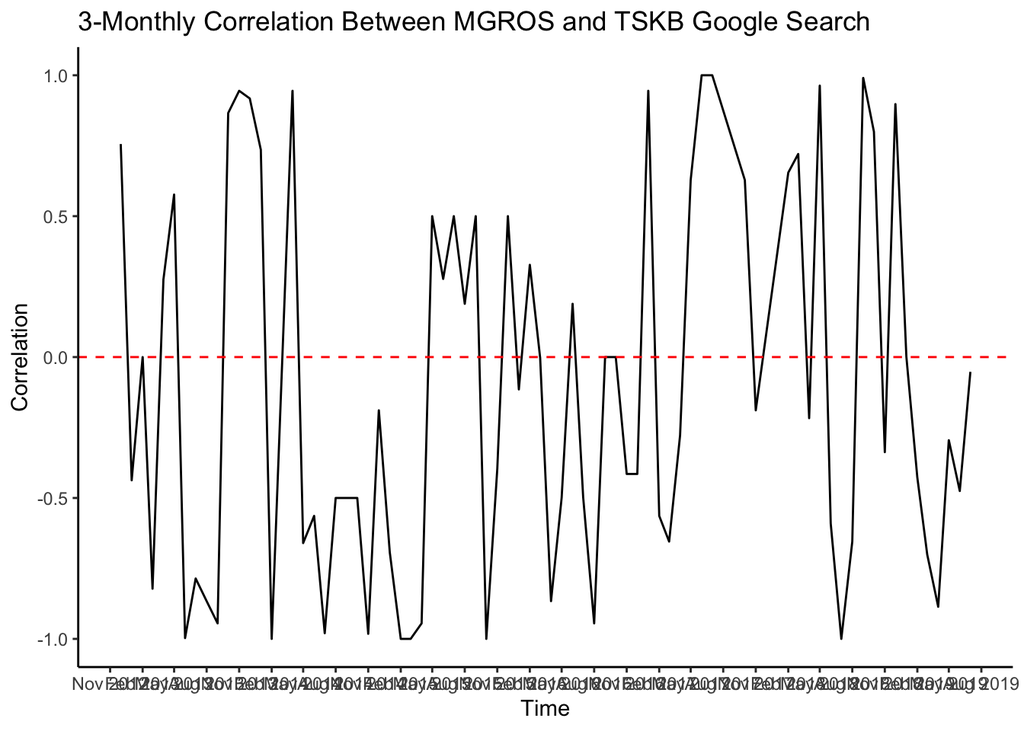

```r
# Visualize the monthly correlations
MT_correlations = na.omit(MT_correlations)
ggplot(MT_correlations, aes(x = Month, y = corr)) +
  geom_line() +
  scale_x_date(date_breaks = "3 months", date_labels = "%b %Y") +
  labs(title = "3-Monthly Correlation Between MGROS and TSKB Google Search",
       x = "Time",
       y = "Correlation") +
  geom_hline(yintercept = 0, linetype = "dashed", color = "red")+
  theme(panel.grid.major = element_blank(), panel.grid.minor = element_blank(),
        panel.background = element_blank(), axis.line = element_line(colour = "black"))
```

- **SAHOL-TTKOM**

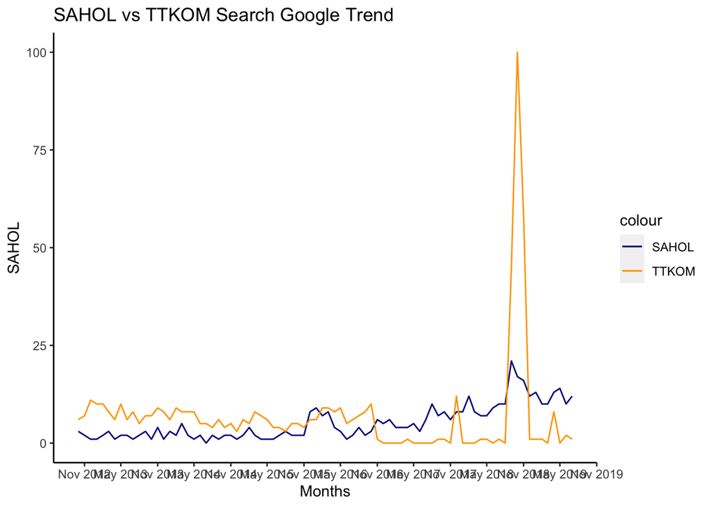

```r
ggplot(sahol_ttkom, aes(x = Month)) +
  geom_line(aes(y=SAHOL,colour="SAHOL")) +
  geom_line(aes(y=TTKOM, colour= "TTKOM")) +
  scale_x_date(date_breaks = "6 months", date_labels = "%b %Y") +
  labs(title = "SAHOL vs TTKOM Search Google Trend",
       x = "Months") +
  scale_color_manual(values = c("SAHOL" = "darkblue", "TTKOM" = "orange")) +
  theme(panel.grid.major = element_blank(), panel.grid.minor = element_blank(),
        panel.background = element_blank(), axis.line = element_line(colour = "black"))
```

Again, looking at the correlation information in the Google trends data for the “IST:SAHOL” and “IST:TTKOM”:

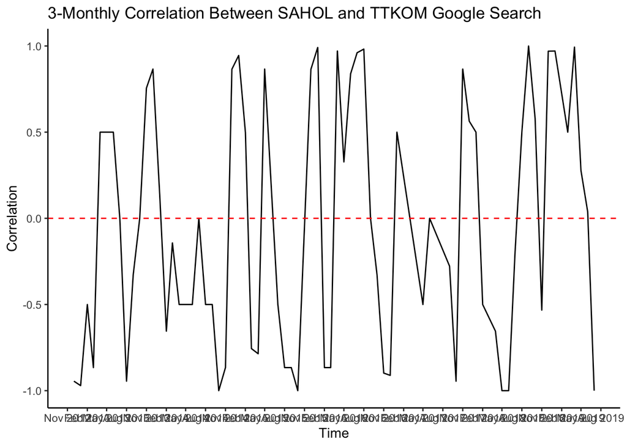

```r
# Visualize the monthly correlations
ST_correlations <- na.omit(ST_correlations)
ggplot(ST_correlations, aes(x = Month, y = corr)) +
  geom_line() +
  scale_x_date(date_breaks = "3 months", date_labels = "%b %Y") +
  labs(title = "3-Monthly Correlation Between SAHOL and TTKOM Google Search",
       x = "Time",
       y = "Correlation") +
  geom_hline(yintercept = 0, linetype = "dashed", color = "red")+
  theme(panel.grid.major = element_blank(), panel.grid.minor = element_blank(),
        panel.background = element_blank(), axis.line = element_line(colour = "black"))
```